# NY City Restaurant Data Analysis

Sekhar Mekala  
05/26/2015

### Data Source

**Data Source**

- Data about NY City restaurants ratings, inspection details and citations is publicly available at https://data.cityofnewyork.us/Health/DOHMH-New-York-City-Restaurant-Inspection-Results/xx67-kt59
- This data gets updated almost daily
- Lower the restaurant's score, better is the restaurant
- Each restaurant is inspected at least once an year and these happen suddenly, without any notice

### Business requirements

- Which factor(s) affect the number of days between restaurant's inspection?
- Which factor(s) affect the closure of a restaurant, in the current inspection?
- Which factors affect the closure of a restaurant, in the next inspection?
- Can we predict the above three with some degree of certainity?

### Data Munging

- Data is loaded into normalized RDBMS tables. RDBMS tables help us to manage the data efficiently, and these can be updated daily with new data
- The data needed for analysis is obtained in the form of a CSV file(s) from RDBMS Tables
- The CSV files obtained from RDBMS ate loaded at www.github.com. These files are accessed by R programs for data analysis
- Data is transformed, and two types of data sets are produced for training and model testing (…Cont)

### Data Munging

- R language is used to transform the data to the required format (data frames)
- The model training data is taken from all the years data except the data from 2015 year
- The model testing data is taken from the 2015 year's data

### RDBMS Data Model

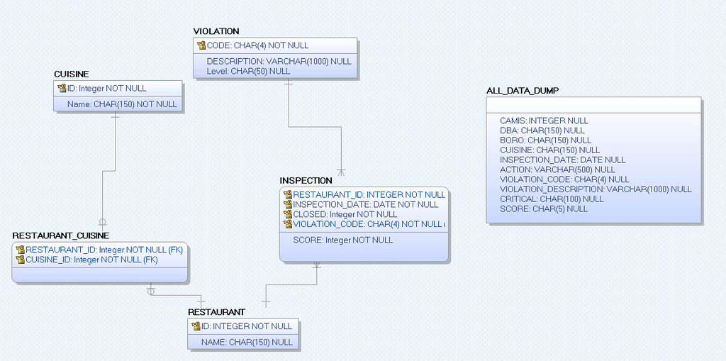

### Model development and evaluation - I

- Found that the “score” variable alone shows strong relationship with the days between the successive inspections

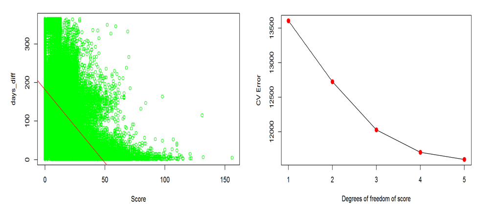

### Model development and evaluation - II

- Predicting if a restaurant will be closed, based on the current citations, score and other variables

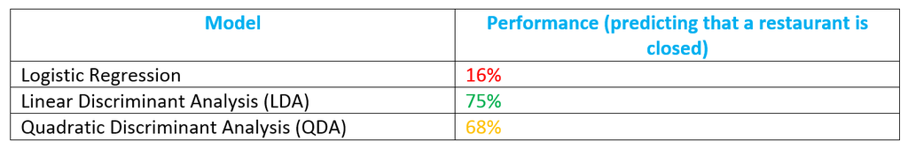

LDA has better performance

### Model development and evaluation - III

- Predicting if a restaurant will be closed in the next visit, based on the current citations, score and other variables

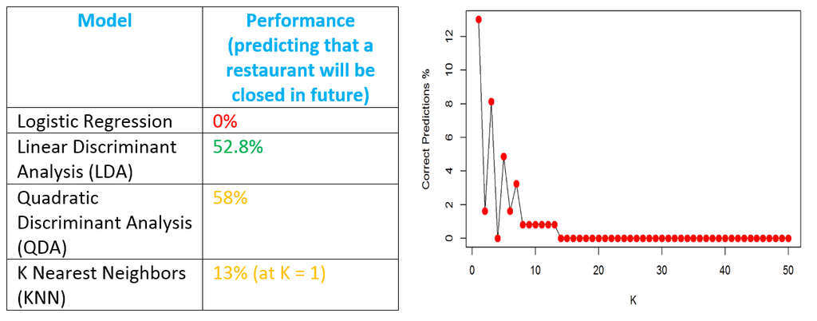

QDA has better performance

### R Code

RPUBS at http://www.rpubs.com/msekhar12/MSDA_607_Final_Project

The source code and data files are present at the following location: https://github.com/msekhar12/MSDA_FINAL_PROJECT/tree/master